# git concepts simplified

Sitaram Chamarty (sitaramc@gmail.com)

# 1 preface

# 1.1 about this slideshow

If you’re viewing this on “gitolite.com”, please be aware that’s only an artifact of some very lazy DNS and hosting decisions I made. Just think of it as “sitaramc.github.com” instead, because these pages really have nothing to do with gitolite per se. They’re about git in general.

# 1.2 license

3. Copyright Sitaram Chamarty, sitaramc@gmail.com. This documentation is provided under a [Creative Commons Attribution-NonCommercial-ShareAlike 3.0 Unported License](https://creativecommons.org/licenses/by-nc-sa/3.0/).

# 1.3 viewing This slideshow

This presentation uses [HTML Slidy](https://www.w3.org/Talks/Tools/Slidy2/Overview.html), a simple presentation software from the W3C. Although there’s a help button in the footer of each presentation, it’s missing some important stuff, so here’s a smaller but more complete summary of the keyboard controls.

[output not shown]

<**To search**> for stuff in the full document using your browser’s Ctrl-F, first view all slides (press the “A” key).

# 1.4 acknowledgements

### this document

This document is vaguely inspired by https://eagain.net/articles/git-for-computer-scientists, except this page is not *just* for CS folks. And it’s a lot more detailed. Oh, and it’s actively maintained, meaning I will respond to feedback ;-)

### this slide show

This slide show was all done with pandoc’s slidy output mode, and a few little pre-processing tweaks. [Pandoc](https://johnmacfarlane.net/pandoc/) is absolutely fantastic and bloody powerful! I wish I’d discovered it sooner but now (Dec 2013) that I have, it’s eliminating a lot of my home-grown scripts to do various things like this!

The bulk of my tweaks are in terms of embedding [graphviz](https://graphviz.org/) diagrams inside the main document, so there’s only one file to maintain!

# 2 basics

# 2.1 what is a SHA

A commit is uniquely identified by a 160-bit hex value (the ‘SHA’). This is computed from the following pieces of information:

- the SHA of the “tree” of files and directories as they exist in that commit (details on how that SHA is computed is not relevant here)
- the SHA of the parent commit(s) – every commit except the very first one in the repo has at least one parent commit that the change is based upon.
- the commit message – what you type in the editor when you commit
- the author name/email/timestamp
- the committer name/email/timestamp

In the end, as I said, it’s just a large, apparently random looking, number, which is actually a cryptographically-strong checksum. It’s usually written out as 40 hex digits.

Humans are not expected to remember this number. For the purposes of this discussion, think of it as something similar to a memory address returned by malloc().

It is also GLOBALLY unique! No commit in any repo anywhere in the world will have the same SHA. (It’s not a mathematical impossibility, but just so extremely improbable that we take it as fact. If you didn’t understand that, just take it on faith).

An example SHA: `a30236028b7ddd65f01321af42f904479eaff549`

# 2.2 what is a “ref”

A ref is just a name for a SHA. Branches or tags (described later) are refs.

There are also some special refs (the most common being `HEAD`), that are usually **symbolic** refs (i.e., they usually point to a ref instead of directly pointing to a SHA).

Anyway, for now just think of them as a human-readable name you gave to a SHA.

# 2.3 what is a repo

A repository (‘repo’) is a graph of commits. In our figures, we represent SHAs with numbers for convenience. We also represent time going upward (bottom to top).

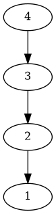

a simple chain of commits

# **(Hey, why are the arrows backward in your pictures?)**

So why are the arrows pointing backward?

Well… every commit knows what its parent commit is (as described in the “what is a SHA” section above). But it can’t know what it’s child commits are – they haven’t been made yet!

Therefore a repo is like a single linked list. It cannot be a double linked list – this is because any change to the contents would change the SHA!

# 3 branches and tags

# 3.1 branch

Traditionally, the top of a linked list has a name. That name is a BRANCH name. We show branch names in green circles.

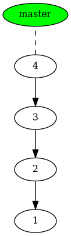

a branch

# 3.2 more than one branch

(a.k.a “more than one child commit”)

Remember we said a repo is a GRAPH? Specifically, more than one child node may be pointing at the same parent node. In this case, each ‘leaf node’ is a branch, and will have a name.

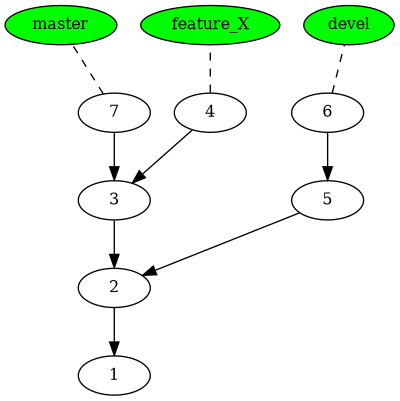

three branches

# 3.3 more than one parent commit

Well we can’t keep creating more branches without eventually merging them back. So let’s say “feature X” is now tested enough to be merged into the main branch, so you `git merge feature_X`. Here’s what you get:

Notice that commit 8 now has 2 parents, showing that it is a “merge commit”.

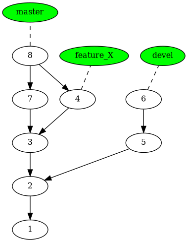

a merge commit

At this point, it’s quite common to delete the feature branch, especially if you anticipate no more “large” changes. So you can run `git branch -d feature_X`, which gives you this:

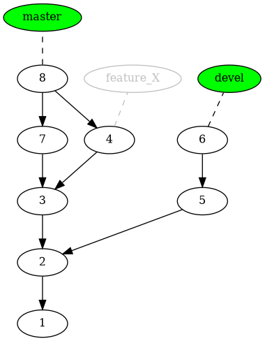

a deleted feature branch

# 3.4 current branch/checked out branch

There is a notion of a ‘currently checked out’ branch. This is denoted by a special ref called HEAD. HEAD is a **symbolic** ref, which points to the ‘current branch’.

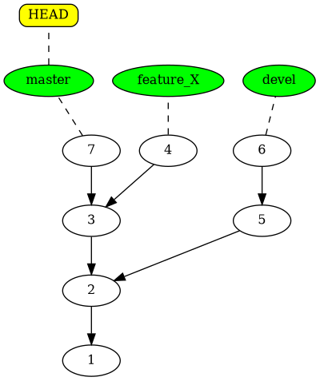

HEAD

# 3.5 committing

When you make a new commit, the current branch moves. Technically, whatever branch HEAD is pointing to will move.

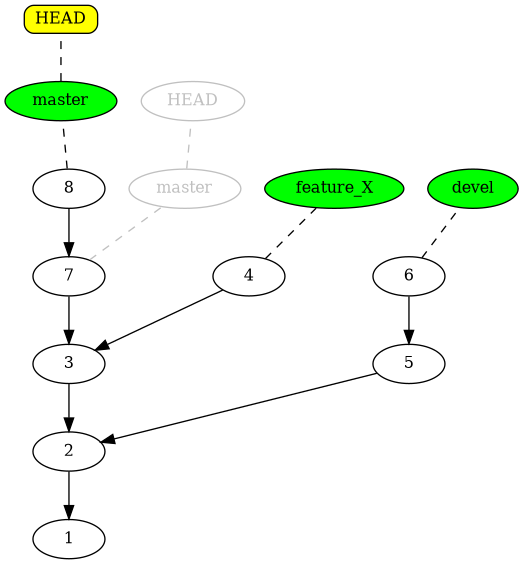

committing

# 3.6 naming non-leaf nodes

It’s not just ‘leaf’ nodes, but inner nodes can also have names. Recall the result of merging `feature_X` earlier (see the “more than one parent commit” section):

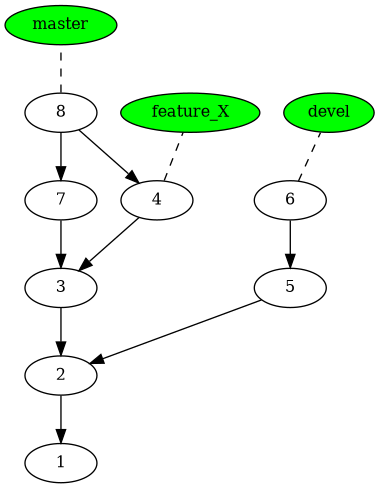

non-leaf

At this point, you could leave `feature_X` as it is forever. Or you could delete the branch (as we showed in that section), in which case that label would simply disappear. (The commit it points to (“4”) is safely reachable from `master` because of the merge. That is, it is not “lost”, since there is a sequence of commits from master which lead to it.)

You can also continue to develop on the `feature_X` branch, further refining it with a view to once again merging it at some later point in time. Although not relevant to the topic of this document, I should mention that the usual practice is to first merge master back into `feature_X` to make sure it has all the other stuff that master may have acquired till now (this is shown by commit 9 below) before continuing further development:

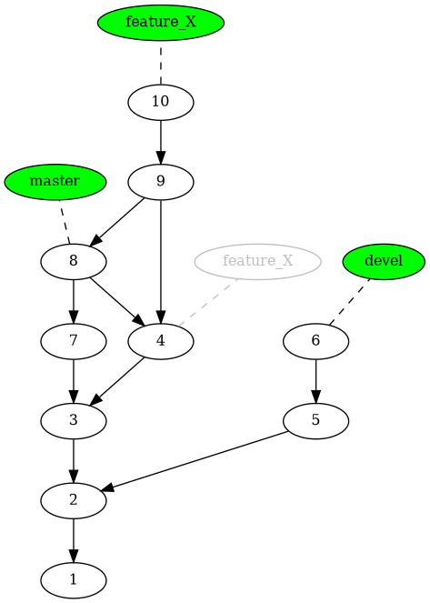

further feature development

# 3.7 tags

More commonly, inner nodes are TAGS. We show tag names in yellow circles.

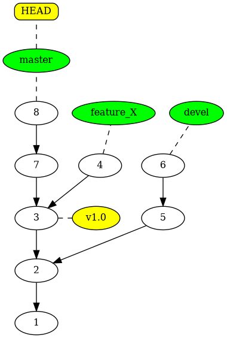

a tag

# 3.8 the difference between branches and tags

The main difference between a branch and a tag is branches move, tags don’t. When you make a commit with the “master” branch currently checked out, master will move to point to the new commit.

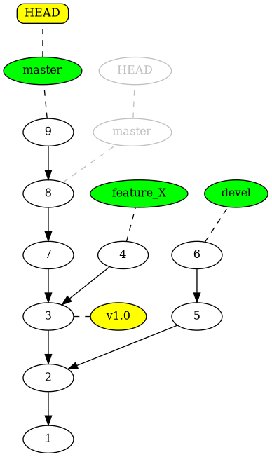

branch versus tag

# 4 digressions - 1

# 4.1 what is a git URL?

Git repos are accessed by providing a URL. There are typically 4 kinds of Git URLs:

- ssh: like `ssh://[user@]host.xz[:port]/path/to/repo.git/`
- http: like `http[s]://host.xz[:port]/path/to/repo.git/`
- git: like `git://host.xz[:port]/path/to/repo.git/` – note that this is an unauthenticated protocol suitable only for allowing downloads of open source or similar software
- local file: like `file:///full/path/to/reponame`

(see ‘man git-clone’ for all the allowed syntaxes for git URLs).

# 4.2 what is a “remote”?

A remote is a short name (like an alias) used to refer to a specific git repository. Instead of always saying `git fetch git://sitaramc/gitolite`, you can add that as a remote and use that short name instead of the long URL.

For convenience, a ‘remote’ called ‘origin’ is automatically created when you clone a repo, pointing to the repo you cloned from.

# 5 local and remote repos

# 5.1 remote branches

Git is a distributed version control system. So when you clone someone’s repo, you get all the branches in that one. Remote branches are prefixed by the name of the remote, and we show them in orange.

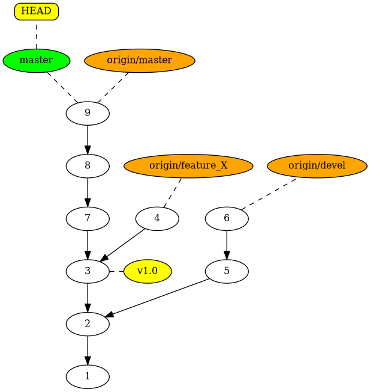

a remote

# 5.2 multiple remotes

You can have several remotes.

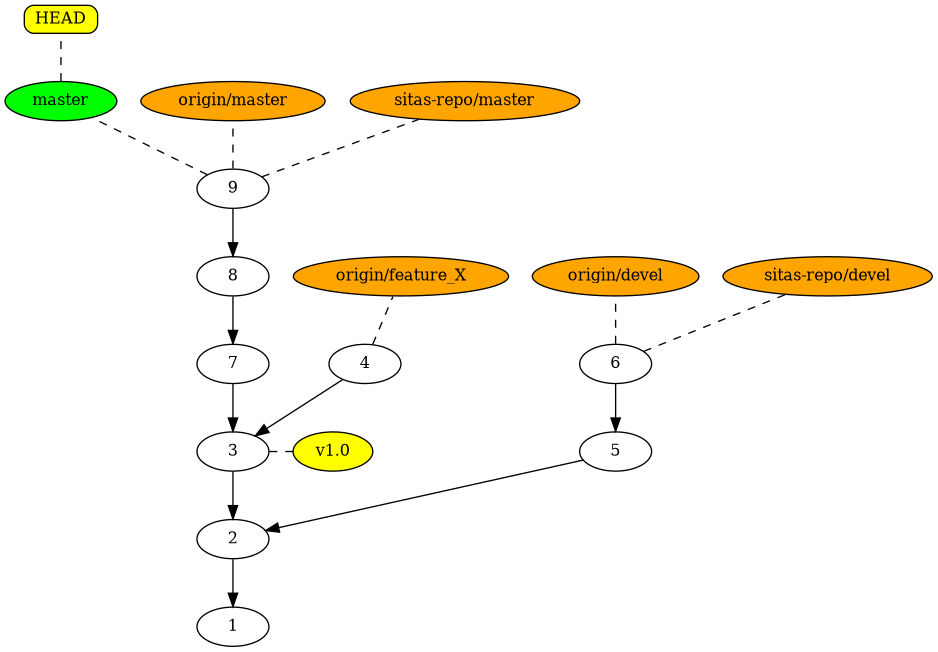

several remotes

# 5.3 fetching and merging from another repo

Now let’s say Sita’s repo had a couple of new commits on its master, and you run `git fetch sitas-repo`. (We have pruned the graph a little for clarity, showing only the relevant commits; the rest of the commits and branches are assumed to be present as in the previous picture).

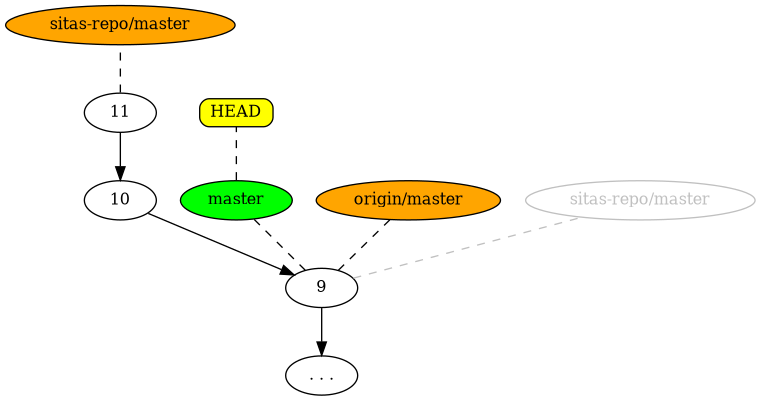

before merge

Now you want to merge Sita’s master branch into yours. Since your master does not have any commits that Sita’s master doesn’t have (i.e., Sita’s master is like a superset of yours), running `git merge sitas-repo/master` will get you this:

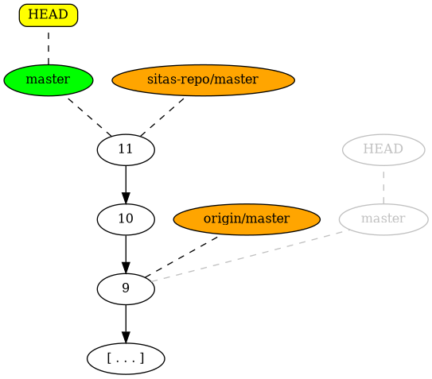

after merge

# 6 digressions - 2

# 6.1 the object store

Git keeps all its data inside a special directory called `.git` at the top level of your repository. Somewhere in there is what we will simply call the *object store* (if you’re not comfortable with that phrase, pretend it’s some sort of database).

Git stores all your data in this object store. There are 4 types of objects in this store:

- **blob** – each file that you add to the repo is turned into a blob object.
- **tree** – each directory is turned into a tree object.

  Obviously, a tree object can contain other tree objects and blob objects, just like a directory can contain other directories and files.
- **commit** – a commit is a snapshot of your working tree at a point in time, although it contains a lot of other information also.
- **tag** – an annotated tag (please see ‘man git-tag’ for more info) contains the SHA of the commit being tagged, some other metadata, and the message. A GPG-signed tag will also contain the GPG signature.

(Details, if you like: a blob is the lowest in the hierarchy. One or more blobs and trees make a tree. A commit is a tree, plus the SHA of its parent commit(s), the commit message, author/committer names and emails, and timestamps. Under normal usage, you don’t need to deal with all this).

# 6.2 what is a repo (again)

Earlier, we saw that a repo was a graph of commits. At the file system level, however, it is basically a directory called `.git` which looks somewhat like this

```
$ ls -al .git
total 40
drwxrwxr-x 7 sitaram sitaram 4096 Sep 14 18:54 ./
drwx------ 3 sitaram sitaram 4096 Sep 14 18:54 ../
drwxrwxr-x 2 sitaram sitaram 4096 Sep 14 18:54 branches/
-rw-rw-r-- 1 sitaram sitaram   92 Sep 14 18:54 config
-rw-rw-r-- 1 sitaram sitaram   73 Sep 14 18:54 description
-rw-rw-r-- 1 sitaram sitaram   23 Sep 14 18:54 HEAD
drwxrwxr-x 2 sitaram sitaram 4096 Sep 14 18:54 hooks/
drwxrwxr-x 2 sitaram sitaram 4096 Sep 14 18:54 info/
drwxrwxr-x 4 sitaram sitaram 4096 Sep 14 18:54 objects/
drwxrwxr-x 4 sitaram sitaram 4096 Sep 14 18:54 refs/
```

# 6.3 objects and branches/tags

The really, **really** important thing to understand is that the object store doesn’t care where the commit came from or what “branch” it was part of when it entered the object store. Once it’s there, it’s there!

Think back to these three diagrams. The first is before you did a fetch.

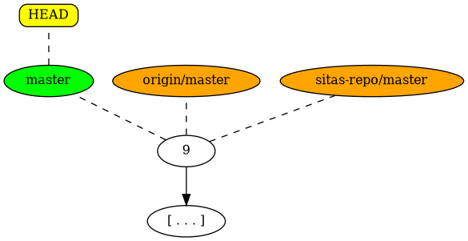

before fetch

The next two figures are after `git fetch sitas-repo` and `git merge sitas-repo/master`, respectively. The fetch command added two new commits (10 and 11) to your object store, along with any other objects those commits reference.

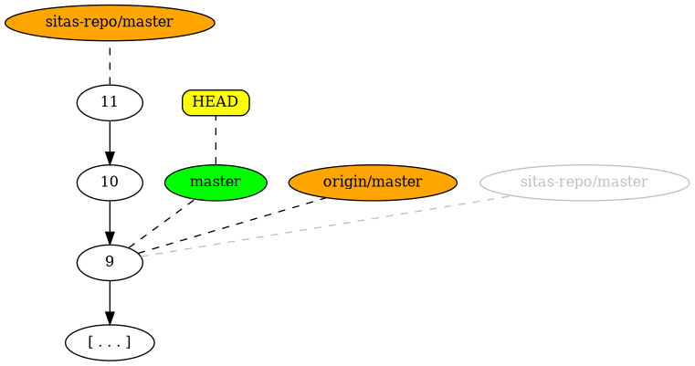

after fetch

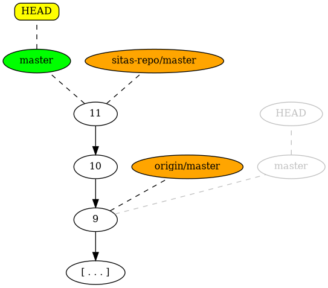

after merge

However, note that commits 10 and 11 did not change in any way simply because they are now in **your local “master” branch**. They continue to have the same SHA values and the object store does not change as a result of this command at all.

All you did was move a pointer from one node to another.

# 7 advanced operations

# 7.1 merging

First, let’s do merging. The merge you saw earlier was what is called a “fast-forward” merge, because your local master did not have any commits that the remote branch you were merging did not have.

In practice, this is rare, especially on an active project with many developers. So let’s see what that looks like. The starting point was this:

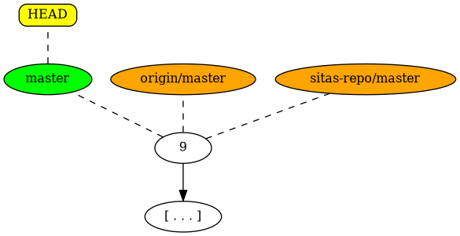

before non-ff merge

Now, you made some changes on your local master. Meanwhile, sitas-repo has had some changes which you got by doing a fetch:

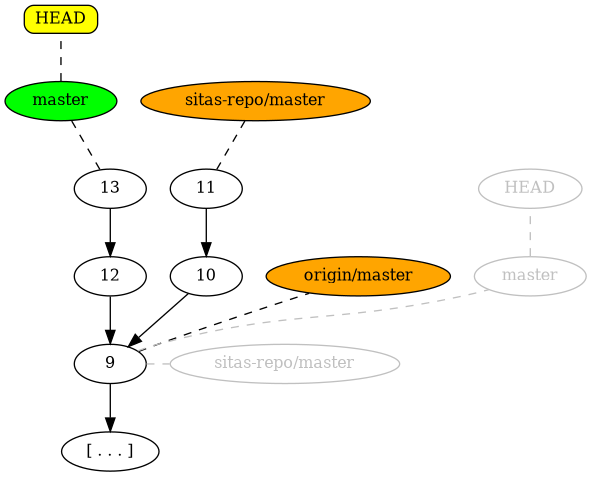

after fetch

When you merge, the end result will usually look like this:

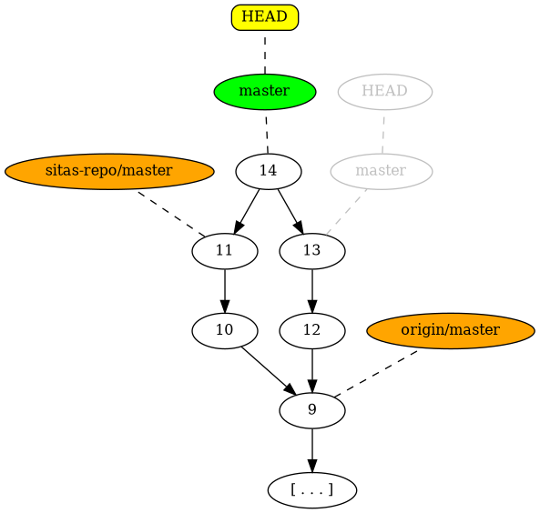

after non-ff merge

# 7.2 cherry-pick

A cherry-pick is not very commonly done – in well designed workflows it should actually be rare. However, it’s a good way to illustrate an important concept in git.

We said before that a commit represents a certain set of files and directories, but since most commits have only one parent, you can think of a commit as representing a set of changes too. (In fact, most older VCSs do this).

Let’s say one of your collaborators (this mythical “Sita” again!) made a whole bunch of changes to his copy of the repo. You don’t like most of these changes, except one specific change which you would like to bring in to your repo.

The starting point is this:

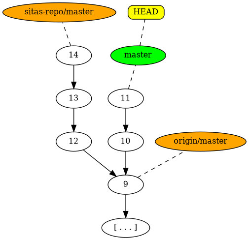

before cherry-pick

Here, sitas-repo has 3 commits on his master (12, 13, and 14) and you are only interested in the change that commit 13 made.

Don’t worry about the meaning of the `~1` for now (although you ought to be able to guess!), but here’s the command you might run:

```
git cherry-pick sitas-repo/master~1
```

This results in the following commit graph.

Note that I’ve called the new commit “13a”. This is to reflect the fact that, while the *change* made is the same as in the original commit 13, the *SHA* will not be the same anymore (new parent commit, new “tree”, new committer name/email, commit time, etc).

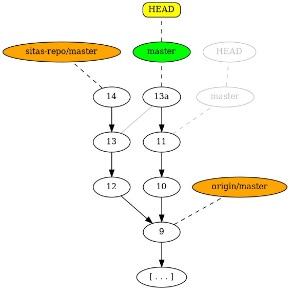

after cherry-pick

# 7.3 rebasing

Instead of merging, let’s say you wanted to rebase your commits on top of Sita’s commits.

First of all, what is rebasing? It’s basically transplanting a series of changes from one point in the graph to another point.

So if you guessed that a rebase was (in principle) a series of cherry-picks, you’d be pretty close, at least from a concept point.

So let’s use a similar example as in the merge example before, but instead of sitas-repo, the new commits are in “origin” (which is the “main” server for this project). You had your own commits, and you did a `git fetch origin` which brought in the latest commits from “origin”, so it looks like:

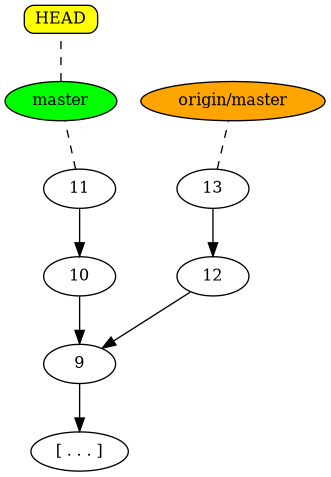

after fetch

Now, instead of merging “origin/master” into your local master, you want to rebase your commits on top of “origin/master”. That is, you want to pretend your local changes were made *after* commit 13 on the origin. So you run `git rebase origin/master`, and this is the result:

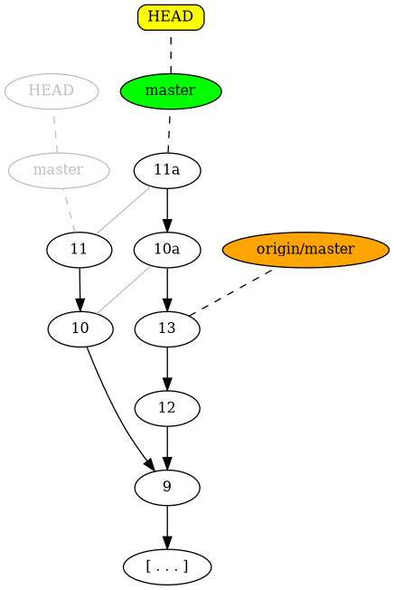

after rebase

Note that again, we’re ignoring command syntax and nuances here. This is about concepts. Also again, note that the SHAs of the 2 commits have changed, since they now have new parents, trees, etc., so we represent that by suffixing an “a”.

Note the *dangling commits* 10 and 11. No branch is now pointing to them, so they’re basically wasted disk space. (They can be examined and reclaimed using the ‘reflog’, or if left alone they will eventually get garbage collected).

Unlike cherry-pick, a rebase is quite often done in real life. Rebase also has some other forms. This form is one, but the most common is when a developer wants to re-arrange his own local commits in a more logical sequence before publishing/pushing them. I often do the eqvt of changing

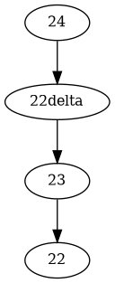

fixup commit

using “git rebase -i”.

Notice that since commit 22 changes its SHA, all its child commits – now rebased – will also have new SHAs. This is why you should (almost) never rebase branches that have already been published.

# 8 tying up some loose ends

# 8.1 the confusion about checkout versus reset

**Please note** that this section completely ignores the myriad options available to both these commands, especially the ones that pertain to the index and the working tree. All we’re trying to do is show what the commands do to the branch and `HEAD`, nothing else. As such, this is not a complete discussion of those two commands, but only about one aspect of them.

In fact, the major reason these two sometimes get confused is that people eventually learn that `git checkout -f` and `git reset --hard` do the same thing, and then extrapolate that to other options. Just remember that both those are specific cases of two quite different commands that just happen to “meet” there, in some sense.

The basic difference is very simple:

- checkout changes what your current branch is (i.e., it changes where HEAD is pointing to)
- reset changes which commit the current branch is pointing to

Here’re some pictures that show you what’s happening. (Note that commits below 6 and 7 are omitted for brevity).

The first picture is the common starting point.

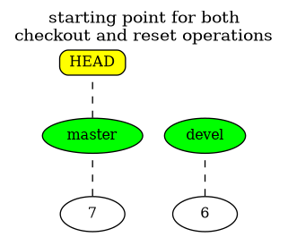

starting point

The next two show the effect of a checkout and a reset, respectively. Notice which line is moving in each picture, compared to the starting point.

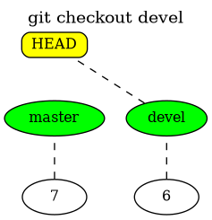

checkout

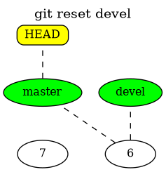

reset

As you can see, your current branch, when you start, is “master” (indicated by where HEAD is pointing).

A “checkout” changes what is your current branch – it is now “devel”, and so any new commits you make now will go on devel, not master.

On the other hand, a reset changes what commit your current branch points to. Your branch is still master, but now it is pointing to what could potentially be a *completely* different history.

(Notice that, like in the rebase example, there is now a dangling commit – one that cannot be reached by any branch. It is still accessible using the ‘reflog’ and will eventually get garbage collected)